# Analysis (steps 7 to 9) - alternate method

2022-05-13

# Introduction

This .rmd uses outputs generated by steps 1-6 of the method.

Inputs are healthy validation set and remaining approx. 34K subjects in the UK Biobank.

This differs from `step7to9diseases.rmd` through a different analysis method. Healthy group used in training no longer used as comparators. Non-diseased subjects compared with diseased subjects in the test set of ~ 34k.

# Disease 1: Diabetes

## (i) propensity match samples

Healthy sample is matched to disease sample by age and sex.

First, examine if there are any differences in covariates:

```
#> # A tibble: 2 × 3
#>   diabetes age_at_MRI   sex
#>   <chr>         <dbl> <dbl>
#> 1 0              63.8 0.485
#> 2 1              65.7 0.633
#>
#>  Welch Two Sample t-test
#>
#> data:  age_at_MRI by diabetes
#> t = -12.099, df = 2883.1, p-value < 2.2e-16
#> alternative hypothesis: true difference in means is not equal to 0
#> 95 percent confidence interval:
#>  -2.170490 -1.565107
#> sample estimates:
#> mean in group 0 mean in group 1
#>        63.82198        65.68978
#>
#>  Welch Two Sample t-test
#>
#> data:  sex by diabetes
#> t = -14.579, df = 2893.1, p-value < 2.2e-16
#> alternative hypothesis: true difference in means is not equal to 0
#> 95 percent confidence interval:
#>  -0.1671843 -0.1275448
#> sample estimates:
#> mean in group 0 mean in group 1
#>       0.4852389       0.6326034
```

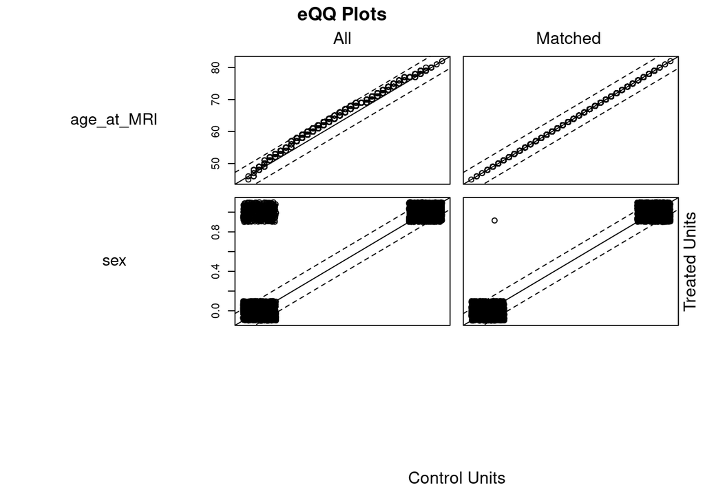

Dimensions of matched data (equal numbers in both groups once matched, number represents total of healthy + disease):

```
#> [1] 4932    8
```

Now compare distributions of matched data:

```
#> # A tibble: 2 × 3
#>   diabetes age_at_MRI   sex
#>   <fct>         <dbl> <dbl>
#> 1 0              65.7 0.633
#> 2 1              65.7 0.633
```

## (ii) analysis

### Summary:

```
#> # A tibble: 2 × 3
#>   diabetes meancatb_delta_with_t1_bc_cole     n
#>   <fct>    <chr>                          <int>
#> 1 0        -0.012                          2466
#> 2 1        0.732                           2466
```

### Plot:

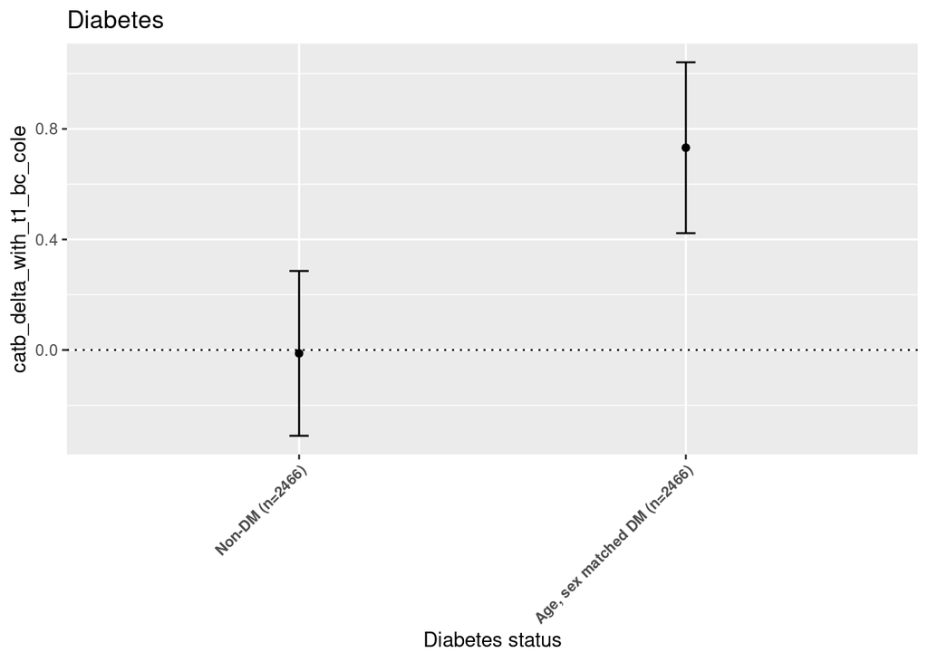

### Regression (adjusted for age, age^2, sex):

```
#>
#> Call:
#> lm(formula = catb_delta_with_t1_bc_cole ~ diabetes + age_at_MRI +
#>     poly(age_at_MRI, 2) + sex, data = dta_m)
#>
#> Residuals:
#>      Min       1Q   Median       3Q      Max
#> -26.6113  -5.0324   0.2662   5.4774  31.6189
#>
#> Coefficients: (1 not defined because of singularities)
#>                       Estimate Std. Error t value Pr(>|t|)
#> (Intercept)            3.63364    0.98267   3.698 0.000220 ***
#> diabetes1              0.74433    0.21724   3.426 0.000617 ***
#> age_at_MRI            -0.06570    0.01479  -4.444 9.04e-06 ***
#> poly(age_at_MRI, 2)1        NA         NA      NA       NA
#> poly(age_at_MRI, 2)2 -54.33391    7.62888  -7.122 1.22e-12 ***
#> sex                    1.05907    0.22602   4.686 2.87e-06 ***
#> ---
#> Signif. codes:  0 '***' 0.001 '**' 0.01 '*' 0.05 '.' 0.1 ' ' 1
#>
#> Residual standard error: 7.628 on 4927 degrees of freedom
#> Multiple R-squared:  0.02028,    Adjusted R-squared:  0.01948
#> F-statistic:  25.5 on 4 and 4927 DF,  p-value: < 2.2e-16
#>                             2.5 %       97.5 %
#> (Intercept)            1.70717008   5.56010525
#> diabetes1              0.31843639   1.17022034
#> age_at_MRI            -0.09468976  -0.03671626
#> poly(age_at_MRI, 2)1           NA           NA
#> poly(age_at_MRI, 2)2 -69.28991091 -39.37791542
#> sex                    0.61596505   1.50218143
```

# Disease 2: Hypertension

## (i) propensity match samples

Healthy sample is matched to disease sample by age and sex.

First, examine if there are any differences in covariates.

```
#> # A tibble: 2 × 3
#>   htn   age_at_MRI   sex
#>   <chr>      <dbl> <dbl>
#> 1 0           63.0 0.459
#> 2 1           66.0 0.573
#>
#>  Welch Two Sample t-test
#>
#> data:  age_at_MRI by htn
#> t = -35.86, df = 23298, p-value < 2.2e-16
#> alternative hypothesis: true difference in means is not equal to 0
#> 95 percent confidence interval:
#>  -3.163513 -2.835608
#> sample estimates:
#> mean in group 0 mean in group 1
#>        62.98623        65.98579
#>
#>  Welch Two Sample t-test
#>
#> data:  sex by htn
#> t = -19.996, df = 21908, p-value < 2.2e-16
#> alternative hypothesis: true difference in means is not equal to 0
#> 95 percent confidence interval:
#>  -0.1259312 -0.1034465
#> sample estimates:
#> mean in group 0 mean in group 1
#>       0.4587700       0.5734589
```

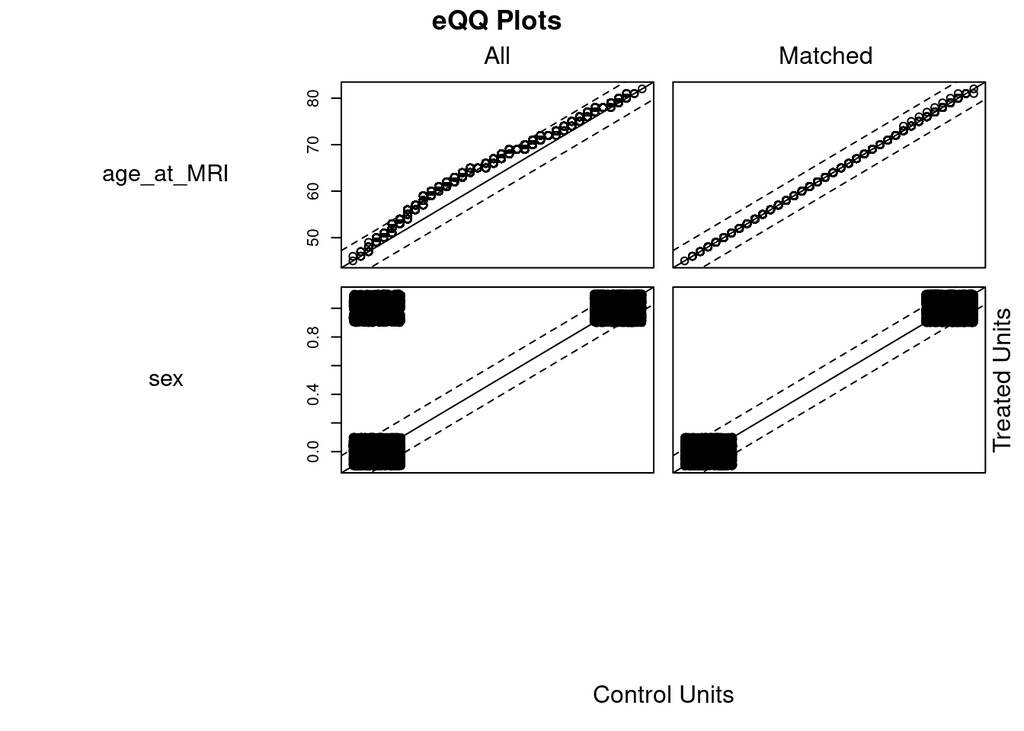

Dimensions of matched data (equal numbers in both groups once matched, number represents total of healthy + htn)

```
#> [1] 22094     8
```

Now compare distributions of matched data

```
#> # A tibble: 2 × 3
#>   htn   age_at_MRI   sex
#>   <fct>      <dbl> <dbl>
#> 1 0           66.0 0.574
#> 2 1           66.0 0.573
```

## (ii) analysis

### Summary:

```
#> # A tibble: 2 × 3
#>   htn   mean_catb_delta_with_t1_bc_cole     n
#>   <fct> <chr>                           <int>
#> 1 0     -0.429                          11047
#> 2 1     1.146                           11047
```

### Plot:

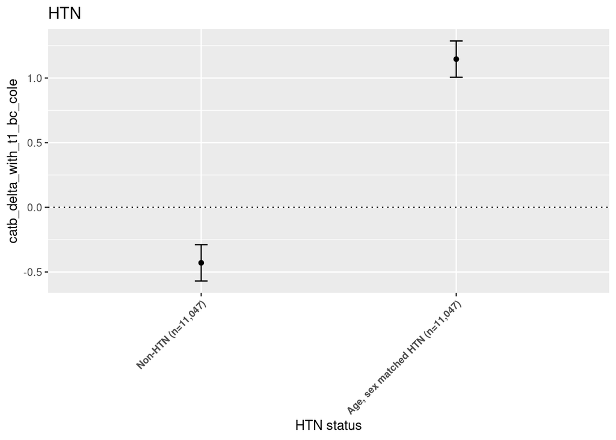

### Regression (adjusted for age, age^2, sex):

```
#>
#> Call:
#> lm(formula = catb_delta_with_t1_bc_cole ~ htn + age_at_MRI +
#>     poly(age_at_MRI, 2) + sex, data = dta_m_htn)
#>
#> Residuals:
#>     Min      1Q  Median      3Q     Max
#> -31.939  -4.878   0.449   5.298  32.789
#>
#> Coefficients: (1 not defined because of singularities)
#>                        Estimate Std. Error t value Pr(>|t|)
#> (Intercept)           4.149e+00  4.779e-01   8.682   <2e-16 ***
#> htn1                  1.575e+00  1.007e-01  15.640   <2e-16 ***
#> age_at_MRI           -7.063e-02  7.158e-03  -9.867   <2e-16 ***
#> poly(age_at_MRI, 2)1         NA         NA      NA       NA
#> poly(age_at_MRI, 2)2 -1.040e+02  7.487e+00 -13.892   <2e-16 ***
#> sex                   1.428e-01  1.020e-01   1.400    0.161
#> ---
#> Signif. codes:  0 '***' 0.001 '**' 0.01 '*' 0.05 '.' 0.1 ' ' 1
#>
#> Residual standard error: 7.486 on 22089 degrees of freedom
#> Multiple R-squared:  0.02364,    Adjusted R-squared:  0.02347
#> F-statistic: 133.7 on 4 and 22089 DF,  p-value: < 2.2e-16
#>                              2.5 %      97.5 %
#> (Intercept)             3.21247615   5.0860497
#> htn1                    1.37791289   1.7727675
#> age_at_MRI             -0.08465871  -0.0565970
#> poly(age_at_MRI, 2)1            NA          NA
#> poly(age_at_MRI, 2)2 -118.69014415 -89.3391606
#> sex                    -0.05712742   0.3427998
```

# Disease 3: Obesity

## (i) propensity match samples

Healthy sample is matched to disease sample by age and sex.

First, examine if there are any differences in covariates.

```
#> # A tibble: 2 × 3
#>   obese age_at_MRI   sex
#>   <chr>      <dbl> <dbl>
#> 1 0           64.0 0.492
#> 2 1           63.7 0.510
```

Dimensions of matched data (equal numbers in both groups once matched, number represents total of healthy + obese)

```
#> [1] 14178     8
```

Now compare distributions of matched data

```
#> # A tibble: 2 × 3
#>   obese age_at_MRI   sex
#>   <fct>      <dbl> <dbl>
#> 1 0           63.7 0.510
#> 2 1           63.7 0.510
```

## (ii) analysis

### Summary:

```
#> # A tibble: 2 × 3
#>   obese mean_catb_delta_with_t1_bc_cole     n
#>   <fct> <chr>                           <int>
#> 1 0     -0.014                           7089
#> 2 1     -0.213                           7089
```

### Plot:

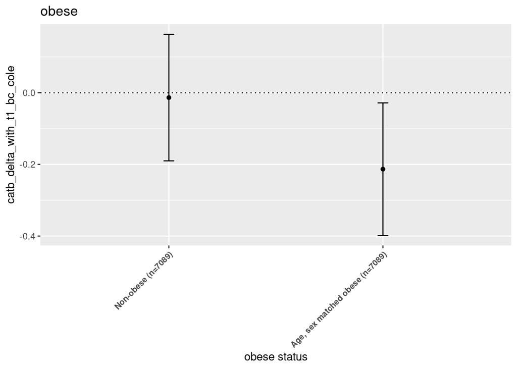

### Regression (adjusted for age, age^2, sex):

```
#>
#> Call:
#> lm(formula = catb_delta_with_t1_bc_cole ~ obese + age_at_MRI +
#>     poly(age_at_MRI, 2) + sex, data = dta_m_obese)
#>
#> Residuals:
#>     Min      1Q  Median      3Q     Max
#> -31.252  -5.208   0.217   5.403  32.376
#>
#> Coefficients: (1 not defined because of singularities)
#>                        Estimate Std. Error t value Pr(>|t|)
#> (Intercept)            0.633346   0.569546   1.112   0.2661
#> obese1                -0.199043   0.129720  -1.534   0.1250
#> age_at_MRI            -0.018115   0.008838  -2.050   0.0404 *
#> poly(age_at_MRI, 2)1         NA         NA      NA       NA
#> poly(age_at_MRI, 2)2 -75.203979   7.729703  -9.729  < 2e-16 ***
#> sex                    0.992237   0.130151   7.624 2.62e-14 ***
#> ---
#> Signif. codes:  0 '***' 0.001 '**' 0.01 '*' 0.05 '.' 0.1 ' ' 1
#>
#> Residual standard error: 7.723 on 14173 degrees of freedom
#> Multiple R-squared:  0.01058,    Adjusted R-squared:  0.0103
#> F-statistic:  37.9 on 4 and 14173 DF,  p-value: < 2.2e-16
#>                             2.5 %        97.5 %
#> (Intercept)           -0.48303859  1.749731e+00
#> obese1                -0.45331138  5.522461e-02
#> age_at_MRI            -0.03543831 -7.926394e-04
#> poly(age_at_MRI, 2)1           NA            NA
#> poly(age_at_MRI, 2)2 -90.35521194 -6.005275e+01
#> sex                    0.73712526  1.247350e+00
```

# Disease 4: Coronary artery disease

## (i) propensity match samples

Healthy sample is matched to cad sample by age and sex.

First, examine if there are any differences in covariates.

```
#> # A tibble: 2 × 3
#>   cad   age_at_MRI   sex
#>   <chr>      <dbl> <dbl>
#> 1 0           63.6 0.475
#> 2 1           67.9 0.739
```

Dimensions of matched data (equal numbers in both groups once matched, number represents total of healthy + cad)

```
#> [1] 5316    8
```

Now compare distributions of matched data

```
#> # A tibble: 2 × 3
#>   cad   age_at_MRI   sex
#>   <fct>      <dbl> <dbl>
#> 1 0           67.9 0.739
#> 2 1           67.9 0.739
```

## (ii) analysis

### Summary:

```
#> # A tibble: 2 × 3
#>   cad   mean_catb_delta_with_t1_bc_cole     n
#>   <fct> <chr>                           <int>
#> 1 0     -0.112                           2658
#> 2 1     -0.152                           2658
```

### Plot:

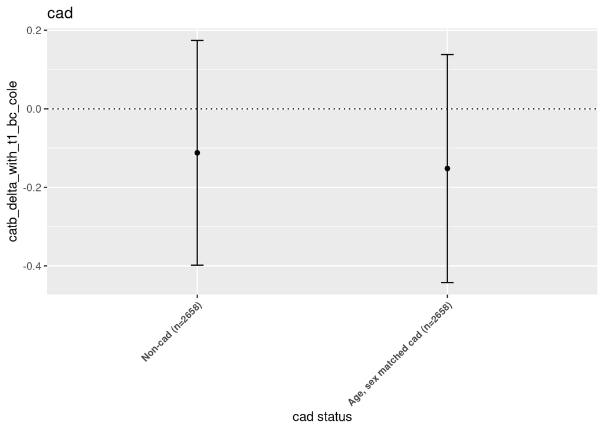

### Regression (adjusted for age, age^2, sex):

```
#>
#> Call:
#> lm(formula = catb_delta_with_t1_bc_cole ~ cad + age_at_MRI +
#>     poly(age_at_MRI, 2) + sex, data = dta_m_cad)
#>
#> Residuals:
#>      Min       1Q   Median       3Q      Max
#> -31.1447  -4.8748   0.4798   5.2996  26.5442
#>
#> Coefficients: (1 not defined because of singularities)
#>                       Estimate Std. Error t value Pr(>|t|)
#> (Intercept)            6.13392    1.08120   5.673 1.48e-08 ***
#> cad1                  -0.03999    0.20688  -0.193    0.847
#> age_at_MRI            -0.09477    0.01574  -6.020 1.86e-09 ***
#> poly(age_at_MRI, 2)1        NA         NA      NA       NA
#> poly(age_at_MRI, 2)2 -31.63494    7.54195  -4.195 2.78e-05 ***
#> sex                    0.25824    0.23608   1.094    0.274
#> ---
#> Signif. codes:  0 '***' 0.001 '**' 0.01 '*' 0.05 '.' 0.1 ' ' 1
#>
#> Residual standard error: 7.542 on 5311 degrees of freedom
#> Multiple R-squared:  0.01013,    Adjusted R-squared:  0.009384
#> F-statistic: 13.59 on 4 and 5311 DF,  p-value: 5.058e-11
#>                            2.5 %       97.5 %
#> (Intercept)            4.0143362   8.25351141
#> cad1                  -0.4455580   0.36558385
#> age_at_MRI            -0.1256297  -0.06390694
#> poly(age_at_MRI, 2)1          NA           NA
#> poly(age_at_MRI, 2)2 -46.4202570 -16.84962348
#> sex                   -0.2045745   0.72106265
```

# Disease 5: Hypercholesterolaemia

## (i) propensity match samples

Healthy sample is matched to chol sample by age and sex.

First, examine if there are any differences in covariates.

```
#> # A tibble: 2 × 3
#>   chol  age_at_MRI   sex
#>   <chr>      <dbl> <dbl>
#> 1 0           63.1 0.458
#> 2 1           67.2 0.629
```

Dimensions of matched data (equal numbers in both groups once matched, number represents total of healthy + chol)

```
#> [1] 14964     8
```

Now compare distributions of matched data

```
#> # A tibble: 2 × 3
#>   chol  age_at_MRI   sex
#>   <fct>      <dbl> <dbl>
#> 1 0           67.2 0.629
#> 2 1           67.2 0.629
```

## (ii) analysis

### Summary:

```
#> # A tibble: 2 × 3
#>   chol  mean_catb_delta_with_t1_bc_cole     n
#>   <fct> <chr>                           <int>
#> 1 0     0.051                            7482
#> 2 1     0.173                            7482
```

### Plot:

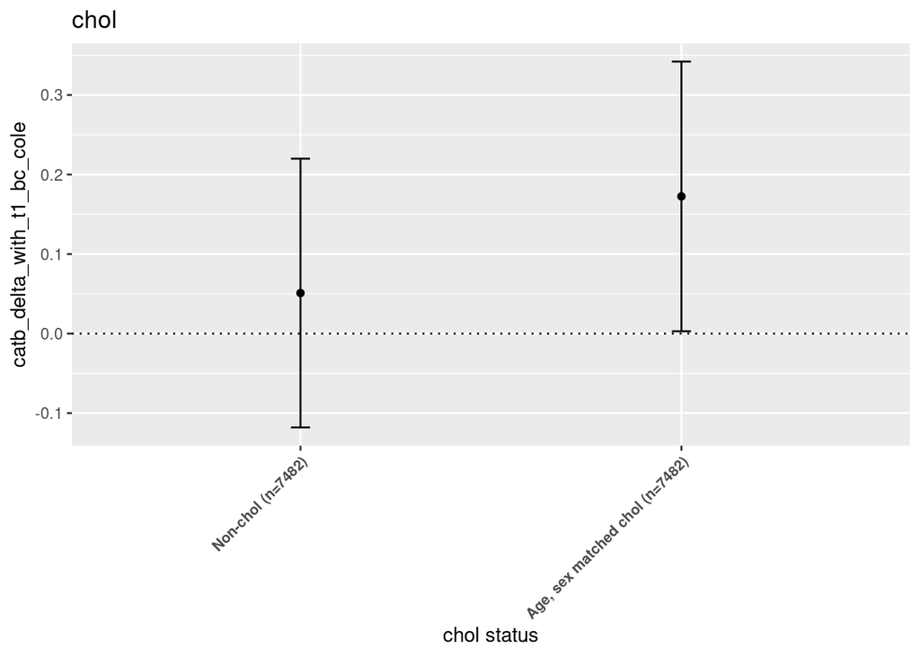

### Regression (adjusted for age, age^2, sex):

```
#>
#> Call:
#> lm(formula = catb_delta_with_t1_bc_cole ~ chol + age_at_MRI +
#>     poly(age_at_MRI, 2) + sex, data = dta_m_chol)
#>
#> Residuals:
#>      Min       1Q   Median       3Q      Max
#> -31.1615  -4.7622   0.5519   5.1935  27.7015
#>
#> Coefficients: (1 not defined because of singularities)
#>                        Estimate Std. Error t value Pr(>|t|)
#> (Intercept)            3.726151   0.624402   5.968 2.46e-09 ***
#> chol1                  0.121580   0.121472   1.001    0.317
#> age_at_MRI            -0.056611   0.009163  -6.178 6.65e-10 ***
#> poly(age_at_MRI, 2)1         NA         NA      NA       NA
#> poly(age_at_MRI, 2)2 -83.625159   7.434344 -11.248  < 2e-16 ***
#> sex                    0.203833   0.125865   1.619    0.105
#> ---
#> Signif. codes:  0 '***' 0.001 '**' 0.01 '*' 0.05 '.' 0.1 ' ' 1
#>
#> Residual standard error: 7.43 on 14959 degrees of freedom
#> Multiple R-squared:  0.01102,    Adjusted R-squared:  0.01075
#> F-statistic: 41.66 on 4 and 14959 DF,  p-value: < 2.2e-16
#>                             2.5 %       97.5 %
#> (Intercept)            2.50224688   4.95005427
#> chol1                 -0.11651984   0.35967950
#> age_at_MRI            -0.07457198  -0.03865075
#> poly(age_at_MRI, 2)1           NA           NA
#> poly(age_at_MRI, 2)2 -98.19738467 -69.05293404
#> sex                   -0.04287803   0.45054436
```

# Risk factor 6: Smoking

## (i) propensity match samples

First, examine if there are any differences in covariates.

```
#> # A tibble: 3 × 3
#>   smoke age_at_MRI   sex
#>   <dbl>      <dbl> <dbl>
#> 1     0       63.1 0.475
#> 2     1       64.6 0.531
#> 3     2       60.7 0.571
```

Dimensions of matched data (equal numbers in both groups once matched, number represents total of healthy + smoke)

```
#> [1] 2330    8
```

Now compare distributions of matched data

```
#> # A tibble: 2 × 3
#>   smoke age_at_MRI   sex
#>   <fct>      <dbl> <dbl>
#> 1 0           60.7 0.571
#> 2 2           60.7 0.571
```

## (ii) analysis

### Summary:

```
#> # A tibble: 2 × 3
#>   smoke mean_catb_delta_with_t1_bc_cole     n
#>   <fct> <chr>                           <int>
#> 1 0     -0.022                           1165
#> 2 2     0.211                            1165
```

### Plot:

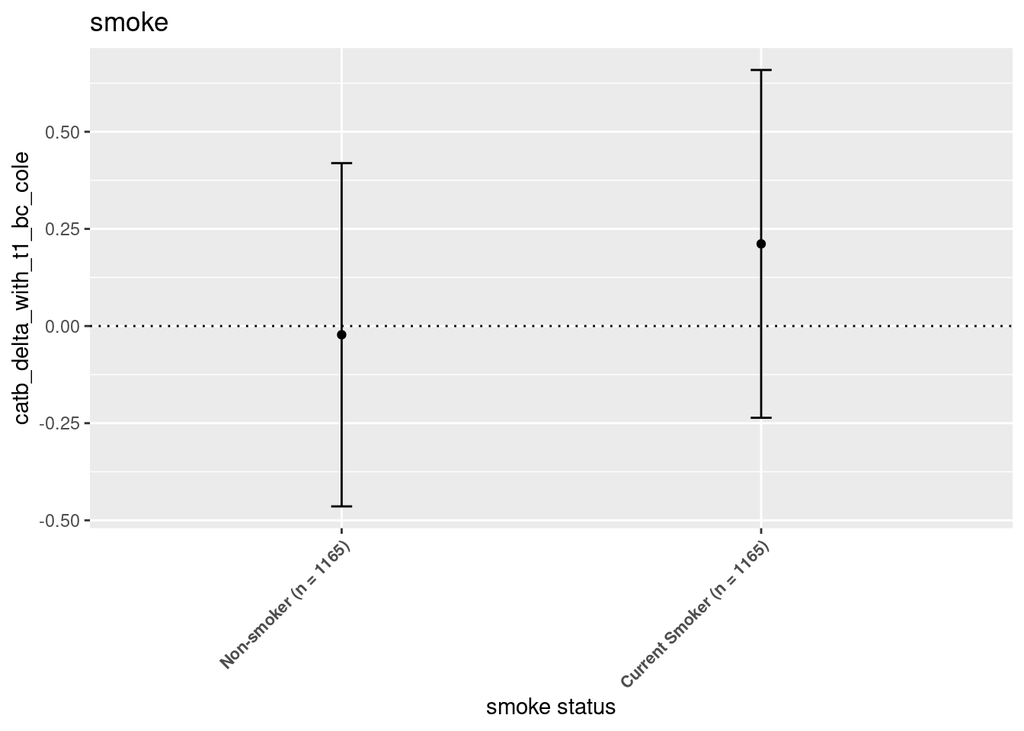

### Regression (adjusted for age, age^2, sex):

```
#>
#> Call:
#> lm(formula = catb_delta_with_t1_bc_cole ~ smoke + age_at_MRI +
#>     poly(age_at_MRI, 2) + sex, data = dta_m_smoke)
#>
#> Residuals:
#>     Min      1Q  Median      3Q     Max
#> -27.002  -5.306   0.167   5.432  30.915
#>
#> Coefficients: (1 not defined because of singularities)
#>                       Estimate Std. Error t value Pr(>|t|)
#> (Intercept)           -2.24917    1.29592  -1.736  0.08277 .
#> smoke2                 0.23387    0.31980   0.731  0.46467
#> age_at_MRI             0.02874    0.02102   1.367  0.17177
#> poly(age_at_MRI, 2)1        NA         NA      NA       NA
#> poly(age_at_MRI, 2)2 -23.71865    7.72334  -3.071  0.00216 **
#> sex                    0.84760    0.32400   2.616  0.00895 **
#> ---
#> Signif. codes:  0 '***' 0.001 '**' 0.01 '*' 0.05 '.' 0.1 ' ' 1
#>
#> Residual standard error: 7.718 on 2325 degrees of freedom
#> Multiple R-squared:  0.007953,   Adjusted R-squared:  0.006247
#> F-statistic:  4.66 on 4 and 2325 DF,  p-value: 0.000953
```

### Smoking - pack years analysis

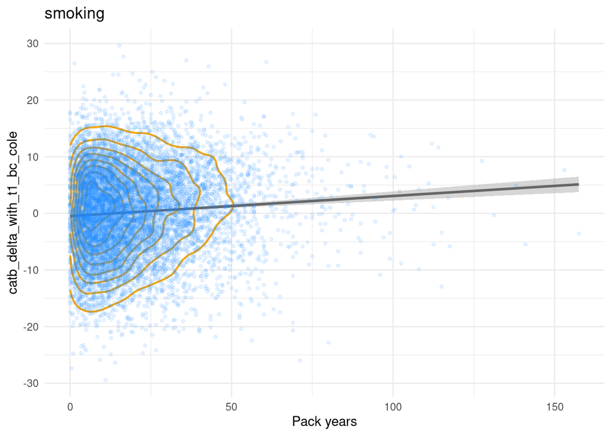

Regular coefficients: and normalised coefficients reported

```r
packyrs_std <- packyrs %>% select(-eid_40616)
packyrs_std = data.frame(scale(packyrs_std))

mod_sm = lm(catb_delta_with_t1_bc_cole ~ packyrs_instance2 + age_at_MRI+ poly(age_at_MRI, 2) + sex  , packyrs)
mod_std_sm = lm(catb_delta_with_t1_bc_cole ~ packyrs_instance2 + age_at_MRI+ poly(age_at_MRI, 2) + sex  , packyrs_std)
```

| Observations | 9283 |
| --- | --- |
| Dependent variable | catb_delta_with_t1_bc_cole |
| Type | OLS linear regression |

| F(4,9278) | 37.71 |
| --- | --- |
| R² | 0.02 |
| Adj. R² | 0.02 |

|  | Est. | S.E. | t val. | p |
| --- | --- | --- | --- | --- |
| (Intercept) | -0.71 | 0.69 | -1.02 | 0.31 |
| packyrs_instance2 | 0.03 | 0.01 | 6.16 | 0.00 |
| age_at_MRI | -0.00 | 0.01 | -0.19 | 0.85 |
| poly(age_at_MRI, 2)1 | NA | NA | NA | NA |
| poly(age_at_MRI, 2)2 | -67.94 | 7.60 | -8.94 | 0.00 |
| sex | 0.79 | 0.16 | 4.94 | 0.00 |

Standard errors: OLS

Normalised coefficient:

| Observations | 9283 |
| --- | --- |
| Dependent variable | catb_delta_with_t1_bc_cole |
| Type | OLS linear regression |

| F(4,9278) | 37.71 |
| --- | --- |
| R² | 0.02 |
| Adj. R² | 0.02 |

|  | Est. | S.E. | t val. | p |
| --- | --- | --- | --- | --- |
| (Intercept) | 0.00 | 0.01 | 0.00 | 1.00 |
| packyrs_instance2 | 0.06 | 0.01 | 6.16 | 0.00 |
| age_at_MRI | -0.00 | 0.01 | -0.19 | 0.85 |
| poly(age_at_MRI, 2)1 | NA | NA | NA | NA |
| poly(age_at_MRI, 2)2 | -8.88 | 0.99 | -8.94 | 0.00 |
| sex | 0.05 | 0.01 | 4.94 | 0.00 |

Standard errors: OLS

# Risk factor 7: Alcohol

```r
alcohol <- read_csv("~/cardiac/Ageing/data/y_Mit_datasets/eid_alcohol.csv")
alcohol <- left_join(alcohol, non.healthy.df)
alcohol <- alcohol[complete.cases(alcohol), ]
```

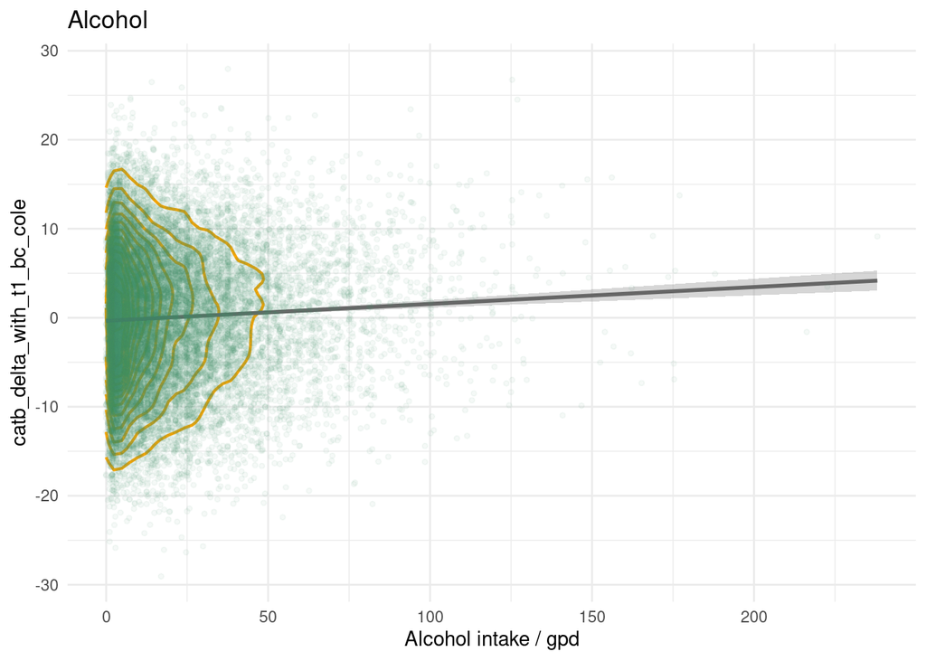

```r
alcohol_std <- alcohol %>% select(-eid_40616)
alcohol_std = data.frame(scale(alcohol_std))

mod_a = lm(catb_delta_with_t1_bc_cole ~ alcoholintakegpd + age_at_MRI+ poly(age_at_MRI, 2) + sex  , alcohol)
mod_std_a = lm(catb_delta_with_t1_bc_cole ~ alcoholintakegpd + age_at_MRI+ poly(age_at_MRI, 2) + sex  , alcohol_std)
```

| Observations | 21374 |
| --- | --- |
| Dependent variable | catb_delta_with_t1_bc_cole |
| Type | OLS linear regression |

| F(4,21369) | 75.21 |
| --- | --- |
| R² | 0.01 |
| Adj. R² | 0.01 |

|  | Est. | S.E. | t val. | p |
| --- | --- | --- | --- | --- |
| (Intercept) | 0.00 | 0.01 | 0.00 | 1.00 |
| alcoholintakegpd | 0.04 | 0.01 | 5.80 | 0.00 |
| age_at_MRI | 0.05 | 0.01 | 7.42 | 0.00 |
| poly(age_at_MRI, 2)1 | NA | NA | NA | NA |
| poly(age_at_MRI, 2)2 | -13.28 | 0.99 | -13.36 | 0.00 |
| sex | 0.02 | 0.01 | 3.49 | 0.00 |

Standard errors: OLS

# Risk factor 8: Telomere Length

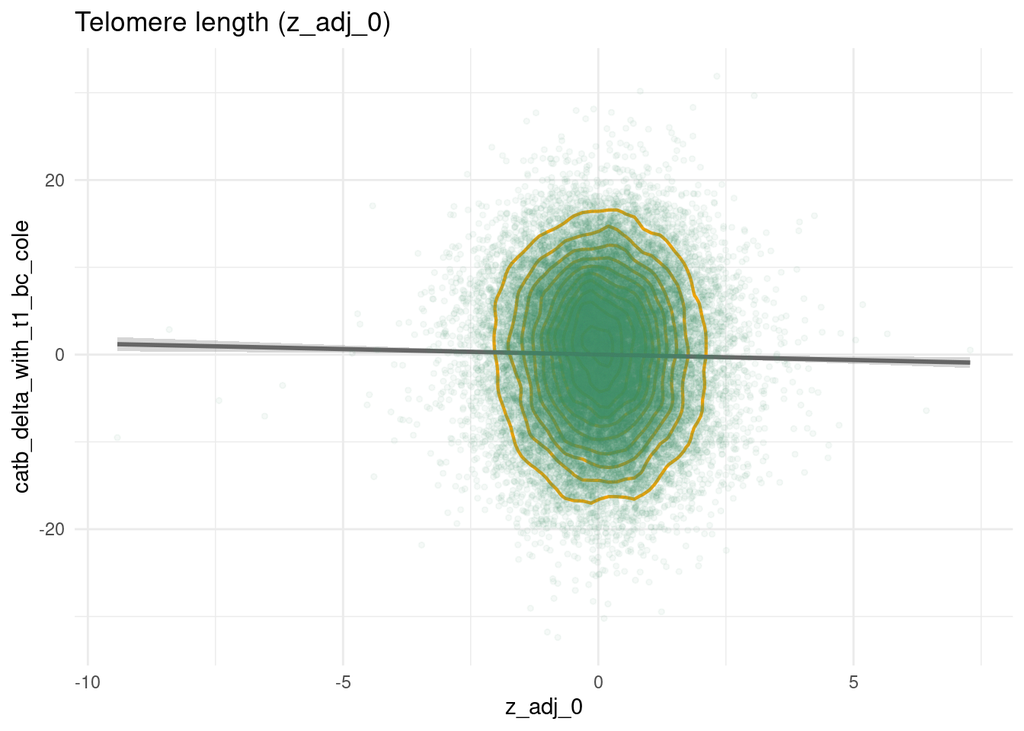

| Observations | 31871 |
| --- | --- |
| Dependent variable | catb_delta_with_t1_bc_cole |
| Type | OLS linear regression |

| F(4,31866) | 89.78 |
| --- | --- |
| R² | 0.01 |
| Adj. R² | 0.01 |

|  | Est. | S.E. | t val. | p |
| --- | --- | --- | --- | --- |
| (Intercept) | -0.00 | 0.01 | -0.00 | 1.00 |
| z_adj_0 | -0.01 | 0.01 | -2.37 | 0.02 |
| age_at_MRI | -0.00 | 0.01 | -0.85 | 0.39 |
| poly(age_at_MRI, 2)1 | NA | NA | NA | NA |
| poly(age_at_MRI, 2)2 | -17.27 | 1.00 | -17.35 | 0.00 |
| sex | 0.04 | 0.01 | 7.73 | 0.00 |

Standard errors: OLS

# Risk factor 9: BMI

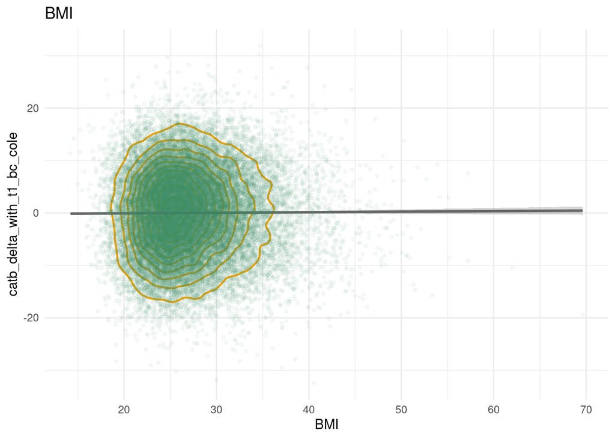

| Observations | 34137 |
| --- | --- |
| Dependent variable | catb_delta_with_t1_bc_cole |
| Type | OLS linear regression |

| F(4,34132) | 91.69 |
| --- | --- |
| R² | 0.01 |
| Adj. R² | 0.01 |

|  | Est. | S.E. | t val. | p |
| --- | --- | --- | --- | --- |
| (Intercept) | 0.00 | 0.01 | 0.00 | 1.00 |
| BMI | 0.00 | 0.01 | 0.29 | 0.77 |
| age_at_MRI | -0.00 | 0.01 | -0.64 | 0.52 |
| poly(age_at_MRI, 2)1 | NA | NA | NA | NA |
| poly(age_at_MRI, 2)2 | -17.58 | 1.00 | -17.65 | 0.00 |
| sex | 0.04 | 0.01 | 8.12 | 0.00 |

Standard errors: OLS

# Forest plot: Categorical variables

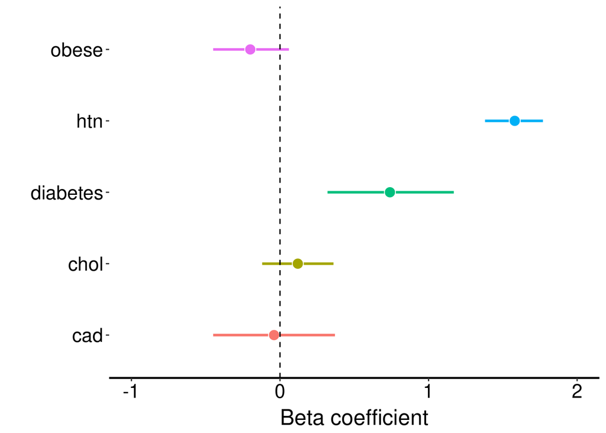

# Forest plot: Continuous variables

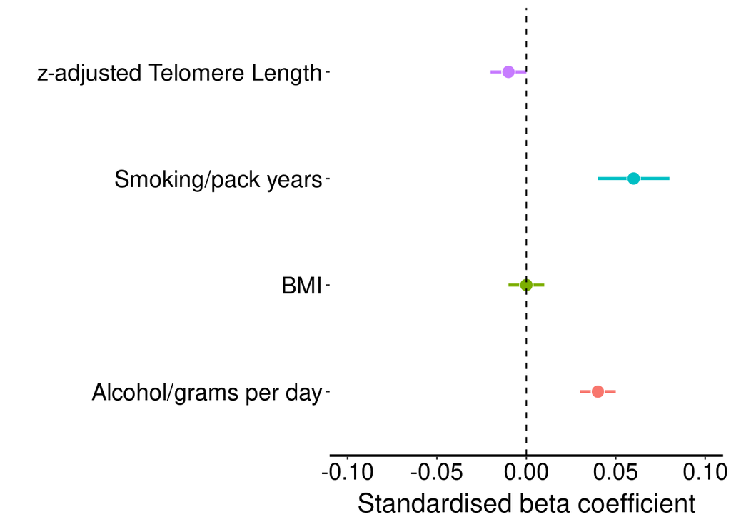